# INSURANCE-CLAIM-FRAUD

```python
import pandas as pd
import numpy as np
import matplotlib.pyplot as plt
import seaborn as sns
```

### IMPORTING THE DATASET

```python
data=pd.read_csv(r'C:\Users\Shashank Sundi\Desktop\I neuron\assignments\INSURANCE FRAUD CLASSIFICATION\insurance_claim_fraud.csv')
pd.set_option("display.max_columns",40)
data
```

|  | months_as_customer | age | policy_number | policy_bind_date | policy_state | policy_csl | policy_deductable | policy_annual_premium | umbrella_limit | insured_zip | insured_sex | insured_education_level | insured_occupation | insured_hobbies | insured_relationship | capital-gains | capital-loss | incident_date | incident_type | collision_type | incident_severity | authorities_contacted | incident_state | incident_city | incident_location | incident_hour_of_the_day | number_of_vehicles_involved | property_damage | bodily_injuries | … |
| --- | --- | --- | --- | --- | --- | --- | --- | --- | --- | --- | --- | --- | --- | --- | --- | --- | --- | --- | --- | --- | --- | --- | --- | --- | --- | --- | --- | --- | --- | --- |
| 0 | 328 | 48 | 521585 | 2014-10-17 | OH | 250/500 | 1000 | 1406.91 | 0 | 466132 | MALE | MD | craft-repair | sleeping | husband | 53300 | 0 | 2015-01-25 | Single Vehicle Collision | Side Collision | Major Damage | Police | SC | Columbus | 9935 4th Drive | 5 | 1 | YES | 1 | … |
| 1 | 228 | 42 | 342868 | 2006-06-27 | IN | 250/500 | 2000 | 1197.22 | 5000000 | 468176 | MALE | MD | machine-op-inspct | reading | other-relative | 0 | 0 | 2015-01-21 | Vehicle Theft | ? | Minor Damage | Police | VA | Riverwood | 6608 MLK Hwy | 8 | 1 | ? | 0 | … |
| 2 | 134 | 29 | 687698 | 2000-09-06 | OH | 100/300 | 2000 | 1413.14 | 5000000 | 430632 | FEMALE | PhD | sales | board-games | own-child | 35100 | 0 | 2015-02-22 | Multi-vehicle Collision | Rear Collision | Minor Damage | Police | NY | Columbus | 7121 Francis Lane | 7 | 3 | NO | 2 | … |
| 3 | 256 | 41 | 227811 | 1990-05-25 | IL | 250/500 | 2000 | 1415.74 | 6000000 | 608117 | FEMALE | PhD | armed-forces | board-games | unmarried | 48900 | -62400 | 2015-01-10 | Single Vehicle Collision | Front Collision | Major Damage | Police | OH | Arlington | 6956 Maple Drive | 5 | 1 | ? | 1 | … |
| 4 | 228 | 44 | 367455 | 2014-06-06 | IL | 500/1000 | 1000 | 1583.91 | 6000000 | 610706 | MALE | Associate | sales | board-games | unmarried | 66000 | -46000 | 2015-02-17 | Vehicle Theft | ? | Minor Damage | None | NY | Arlington | 3041 3rd Ave | 20 | 1 | NO | 0 | … |
| ... | ... | ... | ... | ... | ... | ... | ... | ... | ... | ... | ... | ... | ... | ... | ... | ... | ... | ... | ... | ... | ... | ... | ... | ... | ... | ... | ... | ... | ... | … |
| 995 | 3 | 38 | 941851 | 1991-07-16 | OH | 500/1000 | 1000 | 1310.80 | 0 | 431289 | FEMALE | Masters | craft-repair | paintball | unmarried | 0 | 0 | 2015-02-22 | Single Vehicle Collision | Front Collision | Minor Damage | Fire | NC | Northbrook | 6045 Andromedia St | 20 | 1 | YES | 0 | … |
| 996 | 285 | 41 | 186934 | 2014-01-05 | IL | 100/300 | 1000 | 1436.79 | 0 | 608177 | FEMALE | PhD | prof-specialty | sleeping | wife | 70900 | 0 | 2015-01-24 | Single Vehicle Collision | Rear Collision | Major Damage | Fire | SC | Northbend | 3092 Texas Drive | 23 | 1 | YES | 2 | … |
| 997 | 130 | 34 | 918516 | 2003-02-17 | OH | 250/500 | 500 | 1383.49 | 3000000 | 442797 | FEMALE | Masters | armed-forces | bungie-jumping | other-relative | 35100 | 0 | 2015-01-23 | Multi-vehicle Collision | Side Collision | Minor Damage | Police | NC | Arlington | 7629 5th St | 4 | 3 | ? | 2 | … |
| 998 | 458 | 62 | 533940 | 2011-11-18 | IL | 500/1000 | 2000 | 1356.92 | 5000000 | 441714 | MALE | Associate | handlers-cleaners | base-jumping | wife | 0 | 0 | 2015-02-26 | Single Vehicle Collision | Rear Collision | Major Damage | Other | NY | Arlington | 6128 Elm Lane | 2 | 1 | ? | 0 | … |
| 999 | 456 | 60 | 556080 | 1996-11-11 | OH | 250/500 | 1000 | 766.19 | 0 | 612260 | FEMALE | Associate | sales | kayaking | husband | 0 | 0 | 2015-02-26 | Parked Car | ? | Minor Damage | Police | WV | Columbus | 1416 Cherokee Ridge | 6 | 1 | ? | 0 | … |

1000 rows × 40 columns

### DATA DESCRIPTION

Features:

1. months_as_customer: It denotes the number of months for which the customer is associated with the insurance company.
2. age: continuous. It denotes the age of the person.
3. policy_number: The policy number.
4. policy_bind_date: Start date of the policy.
5. policy_state: The state where the policy is registered.
6. policy_csl-combined single limits. How much of the bodily injury will be covered from the total damage. https://www.berkshireinsuranceservices.com/arecombinedsinglelimitsbetter
7. policy_deductable: The amount paid out of pocket by the policy-holder before an insurance provider will pay any expenses.
8. policy_annual_premium: The yearly premium for the policy.
9. umbrella_limit: An umbrella insurance policy is extra liability insurance coverage that goes beyond the limits of the insured's homeowners, auto or watercraft insurance. It provides an additional layer of security to those who are at risk of being sued for damages to other people's property or injuries caused to others in an accident.
10. insured_zip: The zip code where the policy is registered.
11. insured_sex: It denotes the person's gender.
12. insured_education_level: The highest educational qualification of the policy-holder.
13. insured_occupation: The occupation of the policy-holder.
14. insured_hobbies: The hobbies of the policy-holder.
15. insured_relationship: Dependents on the policy-holder.
16. capital-gain: It denotes the monitory gains by the person.
17. capital-loss: It denotes the monitory loss by the person.
18. incident_date: The date when the incident happened.
19. incident_type: The type of the incident.
20. collision_type: The type of collision that took place.
21. incident_severity: The severity of the incident.
22. authorities_contacted: Which authority was contacted.
23. incident_state: The state in which the incident took place.
24. incident_city: The city in which the incident took place.
25. incident_location: The street in which the incident took place.
26. incident_hour_of_the_day: The time of the day when the incident took place.
27. property_damage: If any property damage was done.
28. bodily_injuries: Number of bodily injuries.
29. Witnesses: Number of witnesses present.
30. police_report_available: Is the police report available.
31. total_claim_amount: Total amount claimed by the customer.
32. injury_claim: Amount claimed for injury
33. property_claim: Amount claimed for property damage.
34. vehicle_claim: Amount claimed for vehicle damage.
35. auto_make: The manufacturer of the vehicle
36. auto_model: The model of the vehicle.
37. auto_year: The year of manufacture of the vehicle.

Target Label: Whether the claim is fraudulent or not.

1. fraud_reported: Y or N

```python
data.columns
```

```
Index(['months_as_customer', 'age', 'policy_number', 'policy_bind_date',
       'policy_state', 'policy_csl', 'policy_deductable',
       'policy_annual_premium', 'umbrella_limit', 'insured_zip', 'insured_sex',
       'insured_education_level', 'insured_occupation', 'insured_hobbies',
       'insured_relationship', 'capital-gains', 'capital-loss',
       'incident_date', 'incident_type', 'collision_type', 'incident_severity',
       'authorities_contacted', 'incident_state', 'incident_city',
       'incident_location', 'incident_hour_of_the_day',
       'number_of_vehicles_involved', 'property_damage', 'bodily_injuries',
       'witnesses', 'police_report_available', 'total_claim_amount',
       'injury_claim', 'property_claim', 'vehicle_claim', 'auto_make',
       'auto_model', 'auto_year', 'fraud_reported', '_c39'],
      dtype='object')
```

### CHECKING AND VALIDATING DTYPES

```python
data.head()
```

|  | months_as_customer | age | policy_number | policy_bind_date | policy_state | policy_csl | policy_deductable | policy_annual_premium | umbrella_limit | insured_zip | insured_sex | insured_education_level | insured_occupation | insured_hobbies | insured_relationship | capital-gains | capital-loss | incident_date | incident_type | collision_type | incident_severity | authorities_contacted | incident_state | incident_city | incident_location | incident_hour_of_the_day | number_of_vehicles_involved | property_damage | bodily_injuries | … |
| --- | --- | --- | --- | --- | --- | --- | --- | --- | --- | --- | --- | --- | --- | --- | --- | --- | --- | --- | --- | --- | --- | --- | --- | --- | --- | --- | --- | --- | --- | --- |
| 0 | 328 | 48 | 521585 | 2014-10-17 | OH | 250/500 | 1000 | 1406.91 | 0 | 466132 | MALE | MD | craft-repair | sleeping | husband | 53300 | 0 | 2015-01-25 | Single Vehicle Collision | Side Collision | Major Damage | Police | SC | Columbus | 9935 4th Drive | 5 | 1 | YES | 1 | … |
| 1 | 228 | 42 | 342868 | 2006-06-27 | IN | 250/500 | 2000 | 1197.22 | 5000000 | 468176 | MALE | MD | machine-op-inspct | reading | other-relative | 0 | 0 | 2015-01-21 | Vehicle Theft | ? | Minor Damage | Police | VA | Riverwood | 6608 MLK Hwy | 8 | 1 | ? | 0 | … |
| 2 | 134 | 29 | 687698 | 2000-09-06 | OH | 100/300 | 2000 | 1413.14 | 5000000 | 430632 | FEMALE | PhD | sales | board-games | own-child | 35100 | 0 | 2015-02-22 | Multi-vehicle Collision | Rear Collision | Minor Damage | Police | NY | Columbus | 7121 Francis Lane | 7 | 3 | NO | 2 | … |
| 3 | 256 | 41 | 227811 | 1990-05-25 | IL | 250/500 | 2000 | 1415.74 | 6000000 | 608117 | FEMALE | PhD | armed-forces | board-games | unmarried | 48900 | -62400 | 2015-01-10 | Single Vehicle Collision | Front Collision | Major Damage | Police | OH | Arlington | 6956 Maple Drive | 5 | 1 | ? | 1 | … |
| 4 | 228 | 44 | 367455 | 2014-06-06 | IL | 500/1000 | 1000 | 1583.91 | 6000000 | 610706 | MALE | Associate | sales | board-games | unmarried | 66000 | -46000 | 2015-02-17 | Vehicle Theft | ? | Minor Damage | None | NY | Arlington | 3041 3rd Ave | 20 | 1 | NO | 0 | … |

```python
pd.DataFrame(data=data.dtypes.values,index=data.dtypes.index).T
```

|  | months_as_customer | age | policy_number | policy_bind_date | policy_state | policy_csl | policy_deductable | policy_annual_premium | umbrella_limit | insured_zip | insured_sex | insured_education_level | insured_occupation | insured_hobbies | insured_relationship | capital-gains | capital-loss | incident_date | incident_type | collision_type | incident_severity | authorities_contacted | incident_state | incident_city | incident_location | incident_hour_of_the_day | number_of_vehicles_involved | property_damage | bodily_injuries | … |
| --- | --- | --- | --- | --- | --- | --- | --- | --- | --- | --- | --- | --- | --- | --- | --- | --- | --- | --- | --- | --- | --- | --- | --- | --- | --- | --- | --- | --- | --- | --- |
| 0 | int64 | int64 | int64 | object | object | object | int64 | float64 | int64 | int64 | object | object | object | object | object | int64 | int64 | object | object | object | object | object | object | object | object | int64 | int64 | object | int64 | … |

```python
# we can observe that-

# Following features should be of type datetime , but are identified as object or numeric
# policy_bind_date , incident_date , auto_year

# We convert them to datetime cuz , We want to create new features from them , instead of dropping them off------Features will be created later on
# claim_duration = policy_bind_date -incident_date ---- then remove the two columns from data , but keep them during html form input
# car_duration = auto_year - incident_date  --- then remove the two columns from data , but keep them during html form input

data.auto_year=pd.to_datetime(data.auto_year,format="%Y")
data.policy_bind_date=pd.to_datetime(data.policy_bind_date)
data.incident_date=pd.to_datetime(data.incident_date)

# Remove following columns-
# _c39 -- contains all nan values , so drop them
# insured_zip, policy_number , incident_location ---- Since all the values are unique and can be unique for every person ,
#                                                    they don't provide any information ; so, we'll drop these features

data=data.drop(['insured_zip', 'policy_number' , 'incident_location', '_c39'],axis=1)
```

```python
print(data.shape)
pd.DataFrame(data=data.dtypes.values,index=data.dtypes.index).T
```

```
(1000, 36)
```

|  | months_as_customer | age | policy_bind_date | policy_state | policy_csl | policy_deductable | policy_annual_premium | umbrella_limit | insured_sex | insured_education_level | insured_occupation | insured_hobbies | insured_relationship | capital-gains | capital-loss | incident_date | incident_type | collision_type | incident_severity | authorities_contacted | incident_state | incident_city | incident_hour_of_the_day | number_of_vehicles_involved | property_damage | bodily_injuries | witnesses | police_report_available | total_claim_amount | … |
| --- | --- | --- | --- | --- | --- | --- | --- | --- | --- | --- | --- | --- | --- | --- | --- | --- | --- | --- | --- | --- | --- | --- | --- | --- | --- | --- | --- | --- | --- | --- |
| 0 | int64 | int64 | datetime64[ns] | object | object | int64 | float64 | int64 | object | object | object | object | object | int64 | int64 | datetime64[ns] | object | object | object | object | object | object | int64 | int64 | object | int64 | int64 | object | int64 | … |

### DESCRIPTIVE STATISTICS

```python
# collecting index of numerical columns
Int=data.dtypes[data.dtypes=='int64'].index
Float=data.dtypes[data.dtypes=='float64'].index
num_index=Int.append(Float)

# collecting index of categorical columns
categ_index=data.dtypes[data.dtypes=='object'].index

# collecting index of datetime columns
date_index=data.dtypes[data.dtypes=='datetime64[ns]'].index
```

```python
data[num_index].describe()
```

|  | months_as_customer | age | policy_deductable | umbrella_limit | capital-gains | capital-loss | incident_hour_of_the_day | number_of_vehicles_involved | bodily_injuries | witnesses | total_claim_amount | injury_claim | property_claim | vehicle_claim | policy_annual_premium |
| --- | --- | --- | --- | --- | --- | --- | --- | --- | --- | --- | --- | --- | --- | --- | --- |
| count | 1000.000000 | 1000.000000 | 1000.000000 | 1.000000e+03 | 1000.000000 | 1000.000000 | 1000.000000 | 1000.00000 | 1000.000000 | 1000.000000 | 1000.00000 | 1000.000000 | 1000.000000 | 1000.000000 | 1000.000000 |
| mean | 203.954000 | 38.948000 | 1136.000000 | 1.101000e+06 | 25126.100000 | -26793.700000 | 11.644000 | 1.83900 | 0.992000 | 1.487000 | 52761.94000 | 7433.420000 | 7399.570000 | 37928.950000 | 1256.406150 |
| std | 115.113174 | 9.140287 | 611.864673 | 2.297407e+06 | 27872.187708 | 28104.096686 | 6.951373 | 1.01888 | 0.820127 | 1.111335 | 26401.53319 | 4880.951853 | 4824.726179 | 18886.252893 | 244.167395 |
| min | 0.000000 | 19.000000 | 500.000000 | -1.000000e+06 | 0.000000 | -111100.000000 | 0.000000 | 1.00000 | 0.000000 | 0.000000 | 100.00000 | 0.000000 | 0.000000 | 70.000000 | 433.330000 |
| 25% | 115.750000 | 32.000000 | 500.000000 | 0.000000e+00 | 0.000000 | -51500.000000 | 6.000000 | 1.00000 | 0.000000 | 1.000000 | 41812.50000 | 4295.000000 | 4445.000000 | 30292.500000 | 1089.607500 |
| 50% | 199.500000 | 38.000000 | 1000.000000 | 0.000000e+00 | 0.000000 | -23250.000000 | 12.000000 | 1.00000 | 1.000000 | 1.000000 | 58055.00000 | 6775.000000 | 6750.000000 | 42100.000000 | 1257.200000 |
| 75% | 276.250000 | 44.000000 | 2000.000000 | 0.000000e+00 | 51025.000000 | 0.000000 | 17.000000 | 3.00000 | 2.000000 | 2.000000 | 70592.50000 | 11305.000000 | 10885.000000 | 50822.500000 | 1415.695000 |
| max | 479.000000 | 64.000000 | 2000.000000 | 1.000000e+07 | 100500.000000 | 0.000000 | 23.000000 | 4.00000 | 2.000000 | 3.000000 | 114920.00000 | 21450.000000 | 23670.000000 | 79560.000000 | 2047.590000 |

```python
data[categ_index].describe()
```

|  | policy_state | policy_csl | insured_sex | insured_education_level | insured_occupation | insured_hobbies | insured_relationship | incident_type | collision_type | incident_severity | authorities_contacted | incident_state | incident_city | property_damage | police_report_available | auto_make | auto_model | fraud_reported |
| --- | --- | --- | --- | --- | --- | --- | --- | --- | --- | --- | --- | --- | --- | --- | --- | --- | --- | --- |
| count | 1000 | 1000 | 1000 | 1000 | 1000 | 1000 | 1000 | 1000 | 1000 | 1000 | 1000 | 1000 | 1000 | 1000 | 1000 | 1000 | 1000 | 1000 |
| unique | 3 | 3 | 2 | 7 | 14 | 20 | 6 | 4 | 4 | 4 | 5 | 7 | 7 | 3 | 3 | 14 | 39 | 2 |
| top | OH | 250/500 | FEMALE | JD | machine-op-inspct | reading | own-child | Multi-vehicle Collision | Rear Collision | Minor Damage | Police | NY | Springfield | ? | NO | Dodge | RAM | N |
| freq | 352 | 351 | 537 | 161 | 93 | 64 | 183 | 419 | 292 | 354 | 292 | 262 | 157 | 360 | 343 | 80 | 43 | 753 |

```python
data[date_index].describe()
```

|  | policy_bind_date | incident_date | auto_year |
| --- | --- | --- | --- |
| count | 1000 | 1000 | 1000 |
| unique | 951 | 60 | 21 |
| top | 1992-04-28 00:00:00 | 2015-02-02 00:00:00 | 1995-01-01 00:00:00 |
| freq | 3 | 28 | 56 |
| first | 1990-01-08 00:00:00 | 2015-01-01 00:00:00 | 1995-01-01 00:00:00 |
| last | 2015-02-22 00:00:00 | 2015-03-01 00:00:00 | 2015-01-01 00:00:00 |

### DATA CLEANING & NULL VALUE IMPUTATION

```python
pd.DataFrame(data=data.isnull().sum().values,index=data.isnull().sum().index).T
```

|  | months_as_customer | age | policy_bind_date | policy_state | policy_csl | policy_deductable | policy_annual_premium | umbrella_limit | insured_sex | insured_education_level | insured_occupation | insured_hobbies | insured_relationship | capital-gains | capital-loss | incident_date | incident_type | collision_type | incident_severity | authorities_contacted | incident_state | incident_city | incident_hour_of_the_day | number_of_vehicles_involved | property_damage | bodily_injuries | witnesses | police_report_available | total_claim_amount | … |
| --- | --- | --- | --- | --- | --- | --- | --- | --- | --- | --- | --- | --- | --- | --- | --- | --- | --- | --- | --- | --- | --- | --- | --- | --- | --- | --- | --- | --- | --- | --- |
| 0 | 0 | 0 | 0 | 0 | 0 | 0 | 0 | 0 | 0 | 0 | 0 | 0 | 0 | 0 | 0 | 0 | 0 | 0 | 0 | 0 | 0 | 0 | 0 | 0 | 0 | 0 | 0 | 0 | 0 | … |

```python
# in above cell, no null values are displayed , cuz the nan values are in the form of an invalid type - ?

data=data.replace('?',np.nan)
pd.DataFrame(data=data.isnull().sum().values,index=data.isnull().sum().index).T
```

|  | months_as_customer | age | policy_bind_date | policy_state | policy_csl | policy_deductable | policy_annual_premium | umbrella_limit | insured_sex | insured_education_level | insured_occupation | insured_hobbies | insured_relationship | capital-gains | capital-loss | incident_date | incident_type | collision_type | incident_severity | authorities_contacted | incident_state | incident_city | incident_hour_of_the_day | number_of_vehicles_involved | property_damage | bodily_injuries | witnesses | police_report_available | total_claim_amount | … |
| --- | --- | --- | --- | --- | --- | --- | --- | --- | --- | --- | --- | --- | --- | --- | --- | --- | --- | --- | --- | --- | --- | --- | --- | --- | --- | --- | --- | --- | --- | --- |
| 0 | 0 | 0 | 0 | 0 | 0 | 0 | 0 | 0 | 0 | 0 | 0 | 0 | 0 | 0 | 0 | 0 | 0 | 178 | 0 | 0 | 0 | 0 | 0 | 0 | 360 | 0 | 0 | 343 | 0 | … |

```python
# getting columns with null values

null_val_cols=data.isnull().sum()[data.isnull().sum()>0].index
null_val_cols
```

```
Index(['collision_type', 'property_damage', 'police_report_available'], dtype='object')
```

```python
for i in null_val_cols:
    print(data[i].value_counts().head(10))
```

```
Rear Collision     292
Side Collision     276
Front Collision    254
Name: collision_type, dtype: int64
NO     338
YES    302
Name: property_damage, dtype: int64
NO     343
YES    314
Name: police_report_available, dtype: int64
```

```python
data['collision_type'].isnull().sum()
```

```
178
```

```python
# Performing Random Sample Imputation for the above columns

for col in null_val_cols:
    rand_samples=data[col].dropna().sample(n=data[col].isnull().sum())
    rand_samples.index=data[col][data[col].isnull()].index
    data.loc[rand_samples.index,col]=rand_samples
```

```python
# All the null values have been imputed

pd.DataFrame(data=data.isnull().sum().values,index=data.isnull().sum().index).T
```

|  | months_as_customer | age | policy_bind_date | policy_state | policy_csl | policy_deductable | policy_annual_premium | umbrella_limit | insured_sex | insured_education_level | insured_occupation | insured_hobbies | insured_relationship | capital-gains | capital-loss | incident_date | incident_type | collision_type | incident_severity | authorities_contacted | incident_state | incident_city | incident_hour_of_the_day | number_of_vehicles_involved | property_damage | bodily_injuries | witnesses | police_report_available | total_claim_amount | … |
| --- | --- | --- | --- | --- | --- | --- | --- | --- | --- | --- | --- | --- | --- | --- | --- | --- | --- | --- | --- | --- | --- | --- | --- | --- | --- | --- | --- | --- | --- | --- |
| 0 | 0 | 0 | 0 | 0 | 0 | 0 | 0 | 0 | 0 | 0 | 0 | 0 | 0 | 0 | 0 | 0 | 0 | 0 | 0 | 0 | 0 | 0 | 0 | 0 | 0 | 0 | 0 | 0 | 0 | … |

### Data Visualization

```python
import joypy
from pandas import plotting
from pandas.plotting import parallel_coordinates

import plotly
import plotly.offline as py
from plotly.offline import init_notebook_mode, iplot
import plotly.graph_objs as go
from plotly import tools
import plotly.figure_factory as ff
init_notebook_mode(connected = True)

import plotly.figure_factory as ff
from bubbly.bubbly import bubbleplot
import plotly_express as px
```

```python
import matplotlib.pyplot as plt
import seaborn as sns
```

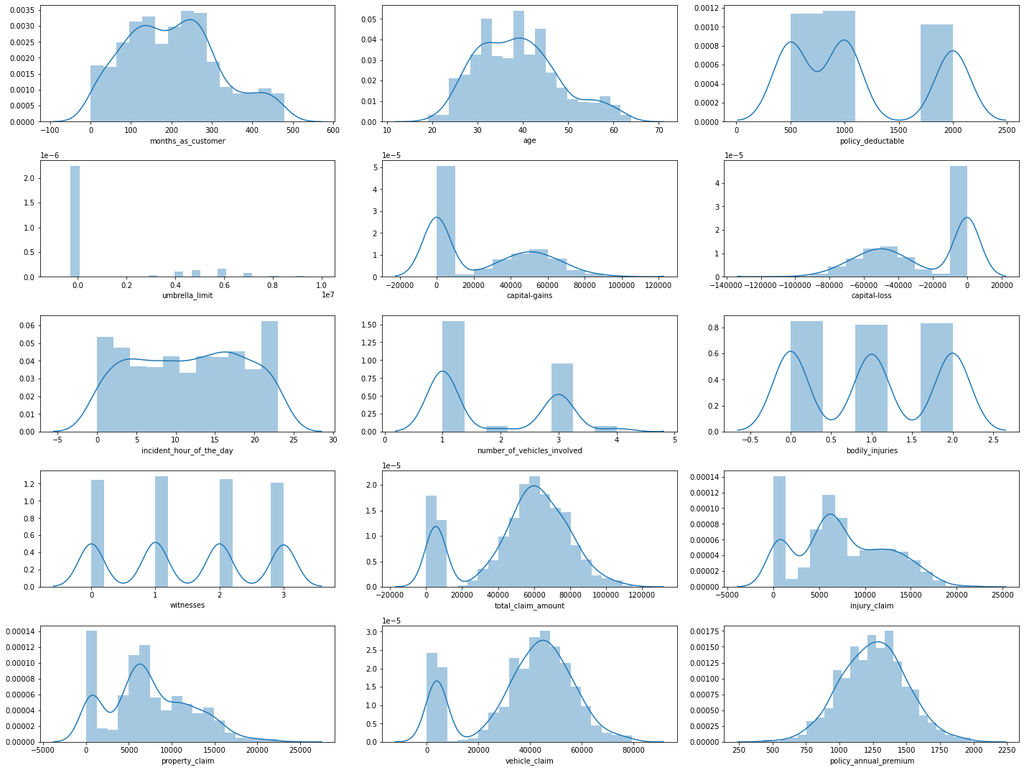

```python
# Checking Distribution of numerical columns

fig,ax=plt.subplots(5,3,figsize=(20,15))

i,j=0,0
for col in num_index:
    sns.distplot(data[col],ax=ax[i,j])
    j+=1
    if j==3:
        i+=1
        j=0

fig.tight_layout()
```

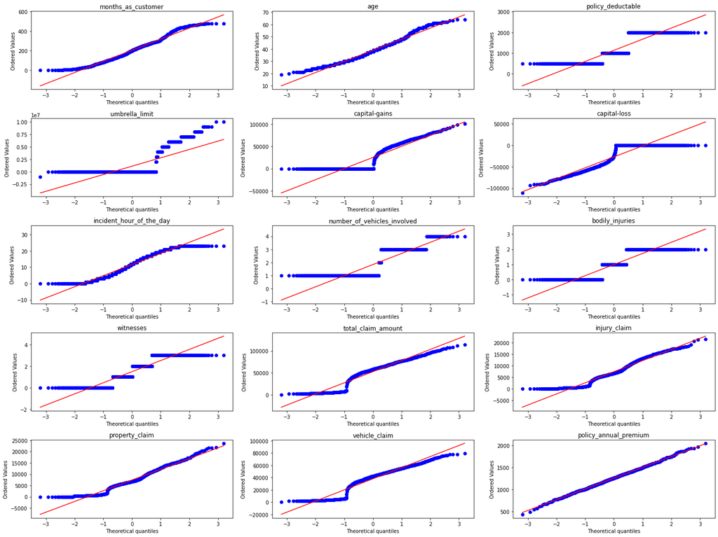

```python
# Checking Normality of numerical columns

from scipy import stats

fig,ax=plt.subplots(5,3,figsize=(20,15))

i,j=0,0
for col in num_index:
    stats.probplot(data[col],plot=ax[i,j])
    ax[i,j].set_title(col)
    j+=1
    if j==3:
        i+=1
        j=0

fig.tight_layout()
```

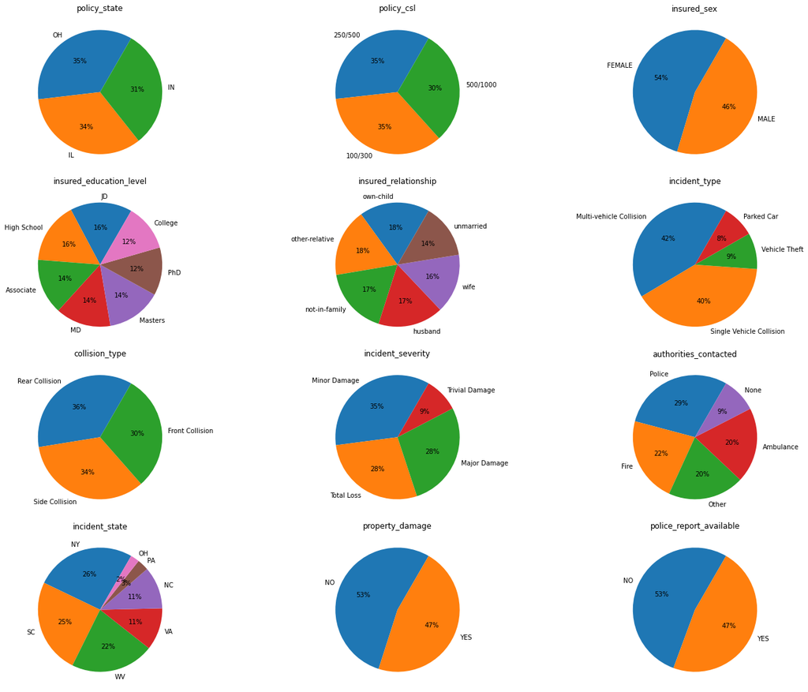

```python
fig,ax=plt.subplots(4,3,figsize=(20,15))

i,j=0,0
for col in categ_index:
    if col in ['insured_occupation', 'insured_hobbies','auto_model','incident_city','auto_make','fraud_reported']:
        continue
    ax[i,j].pie(x=data[col].value_counts(), labels =list(data[col].value_counts().index), autopct='%.0f%%',radius=1,startangle=60)
    ax[i,j].set_title(col)
    j+=1
    if j==3:
        j=0
        i+=1

fig.tight_layout()
plt.show()
```

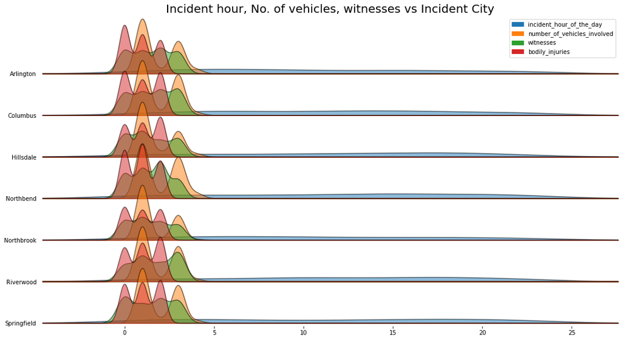

```python
fig, axes = joypy.joyplot(data,
                         column = ['incident_hour_of_the_day','number_of_vehicles_involved', 'witnesses', 'bodily_injuries'],
                         by = 'incident_city',
                         ylim = 'own',
                         figsize = (15,8),
                         alpha = 0.5,
                         legend = True)

plt.title('Incident hour, No. of vehicles, witnesses vs Incident City', fontsize = 20)
plt.show()
```

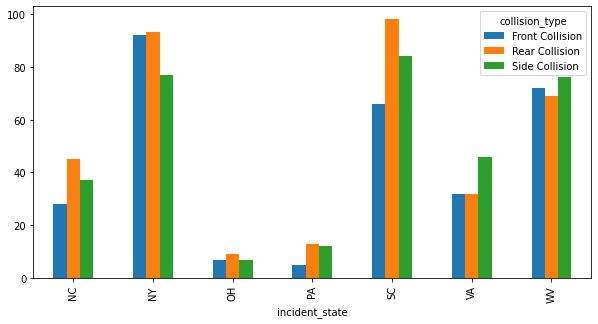

```python
pd.crosstab(data['incident_state'], data['collision_type']).plot(kind='bar',figsize=(10,5))
```

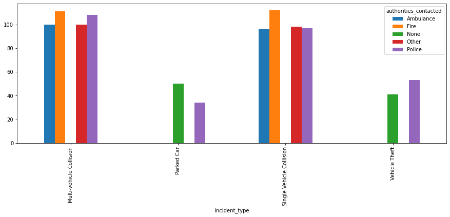

```python
pd.crosstab(data['incident_type'], data['authorities_contacted']).plot(kind='bar',figsize=(15,5))
plt.show()
```

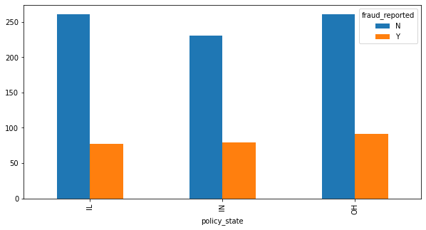

```python
pd.crosstab(data['policy_state'], data['fraud_reported']).sort_values('Y').plot(kind='bar',figsize=(10,5))
plt.show()
```

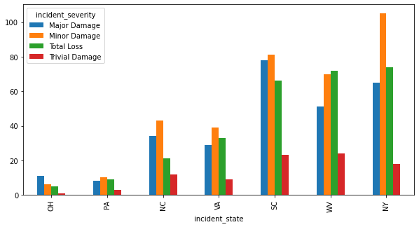

```python
pd.crosstab(data['incident_state'], data['incident_severity']).sort_values('Total Loss').plot(kind='bar',figsize=(10,5))
```

### Encoding the Features

```python
categ_index
```

```
Index(['policy_state', 'policy_csl', 'insured_sex', 'insured_education_level',
       'insured_occupation', 'insured_hobbies', 'insured_relationship',
       'incident_type', 'collision_type', 'incident_severity',
       'authorities_contacted', 'incident_state', 'incident_city',
       'property_damage', 'police_report_available', 'auto_make', 'auto_model',
       'fraud_reported'],
      dtype='object')
```

```python
# Mean Encoding --- policy_state, policy_csl ,insured_hobbies, insured_relationship ,collision_type,incident_state,incident_city,auto_make , auto_model
# Target guided ordinal Encoding --- insured_occupation , incident_severity , authorities_contacted
# One hot --- insured_sex , property damage,police_report_available , fraud reported
# Freq enc -- incident type
# Ordinal enc --- education level
```

```python
# Explation for choosing the respective Encoding Methods

# We did fequency encoding for incident type because its frequency seemed to have a direct relation with the count of fraudulent autcomes
# Mean Encoding for the given columns cuz , those columns didn't have any ordinal order - so no ordinal enc ; have many unique categories - so one hot encoding would lead to
#                                           curse of dimensionality ; their frequency didn't have any relation with the count of fraud outcomes
# One Hot Encoding - for all columns having only two categories
# Target Guided Ordinal Encoding - These features have some ordinal order , but we are not sure of it ; so we rank them in order of how well they predict the Target Variable
```

```python
# One Hot Encoding

sex_map={'MALE':1,'FEMALE':0}
data.insured_sex=data.insured_sex.map(sex_map)

yes_no_map={'YES':1,"NO":0}
data.property_damage=data.property_damage.map(yes_no_map)

data.police_report_available=data.police_report_available.map(yes_no_map)

fraud_map={'Y':1,"N":0}
data.fraud_reported=data.fraud_reported.map(fraud_map)
```

```python
# Mean Encoding

policy_state_map=data.groupby(['policy_state'])['fraud_reported'].mean().to_dict()
# policy_state_map = { 'IL': 0.22781065088757396,'IN': 0.25483870967741934,'OH': 0.2585227272727273 }
data.policy_state=data.policy_state.map(policy_state_map)

policy_csl_map=data.groupby(['policy_csl'])['fraud_reported'].mean().to_dict()
# policy_csl_map={'100/300': 0.25787965616045844,'250/500': 0.2621082621082621,'500/1000': 0.21666666666666667}
data.policy_csl=data.policy_csl.map(policy_csl_map)

insured_hobby_map=data.groupby(['insured_hobbies'])['fraud_reported'].mean().to_dict()
#  insured_hobby_map={'base-jumping': 0.2653061224489796,'basketball': 0.17647058823529413,'board-games': 0.2916666666666667,'bungie-jumping': 0.16071428571428573,'camping': 0.09090909090909091,'chess': 0.8260869565217391,
#                       'cross-fit': 0.7428571428571429, 'dancing': 0.11627906976744186,'exercise': 0.19298245614035087,'golf': 0.10909090909090909,'hiking': 0.23076923076923078,'kayaking': 0.09259259259259259,
#                       'movies': 0.16363636363636364,'paintball': 0.22807017543859648,'polo': 0.2765957446808511,'reading': 0.265625,'skydiving': 0.22448979591836735,'sleeping': 0.1951219512195122,'video-games': 0.2,'yachting': 0.3018867924528302}
data.insured_hobbies=data.insured_hobbies.map(insured_hobby_map)

insured_relation_map=data.groupby(['insured_relationship'])['fraud_reported'].mean().to_dict()
# insured_relation_map={'husband': 0.20588235294117646,'not-in-family': 0.25862068965517243,'other-relative': 0.2937853107344633,'own-child': 0.21311475409836064,'unmarried': 0.24113475177304963,'wife': 0.2709677419354839}
data.insured_relationship=data.insured_relationship.map(insured_relation_map)

collision_map=data.groupby(['collision_type'])['fraud_reported'].mean().to_dict()
# collision_map={'Front Collision': 0.24605678233438485,'Rear Collision': 0.2774566473988439,'Side Collision': 0.2166172106824926}
data.collision_type=data.collision_type.map(collision_map)

incident_state_map=data.groupby(['incident_state'])['fraud_reported'].mean().to_dict()
# incident_state_map = {'NC': 0.3090909090909091,'NY': 0.22137404580152673,'OH': 0.43478260869565216,'PA': 0.26666666666666666,'SC': 0.29435483870967744,'VA': 0.22727272727272727,'WV': 0.17972350230414746}
data.incident_state=data.incident_state.map(incident_state_map)

incident_city_map=data.groupby(["incident_city"])['fraud_reported'].mean().to_dict()
# incident_city_map={'Arlington': 0.2894736842105263,'Columbus': 0.26174496644295303 ,'Hillsdale': 0.24822695035460993 ,'Northbend': 0.23448275862068965 ,'Northbrook': 0.22131147540983606, 'Riverwood': 0.22388059701492538,'Springfield': 0.24203821656050956}
data.incident_city=data.incident_city.map(incident_city_map)

auto_make_map=data.groupby(["auto_make"])['fraud_reported'].mean().to_dict()
# auto_make_map={'Accura': 0.19117647058823528,'Audi': 0.30434782608695654,'BMW': 0.2777777777777778,'Chevrolet': 0.27631578947368424,'Dodge': 0.25,'Ford': 0.3055555555555556,'Honda': 0.2545454545454545,'Jeep': 0.16417910447761194, 'Mercedes': 0.3384615384615385,'Nissan': 0.1794871794871795,'Saab': 0.225,'Suburu': 0.2375,'Toyota': 0.18571428571428572,'Volkswagen': 0.27941176470588236}
data.auto_make=data.auto_make.map(auto_make_map)

# we'll remove this column as it contains too many unique categ values---any manufactureer can have several models
auto_model_map=data.groupby(["auto_model"])['fraud_reported'].mean().to_dict()
data.auto_model=data.auto_model.map(auto_model_map)
```

```python
# Target Guided Ordinal Encoding

occupation_map={j:i+5 for i,j in enumerate(data.groupby(["insured_occupation"])['fraud_reported'].mean().sort_values().index)}
# occupation_map={'other-service': 5,'priv-house-serv': 6,'adm-clerical': 7,'handlers-cleaners': 8,'prof-specialty': 9,'protective-serv': 10,'machine-op-inspct': 11,'armed-forces': 12,'sales': 13,
#                      'tech-support': 14,'transport-moving': 15,'craft-repair': 16,'farming-fishing': 17,'exec-managerial': 18}
data.insured_occupation=data.insured_occupation.map(occupation_map)

severity_map={j:i+5 for i,j in enumerate(data.groupby(["incident_severity"])['fraud_reported'].mean().sort_values().index)}
# severity_map={'Trivial Damage': 5, 'Minor Damage': 6, 'Total Loss': 7, 'Major Damage': 8}
data.incident_severity=data.incident_severity.map(severity_map)

authorities_map={j:i+5 for i,j in enumerate(data.groupby(["authorities_contacted"])['fraud_reported'].mean().sort_values().index)}
# authorities_map={'None': 5, 'Police': 6, 'Fire': 7, 'Ambulance': 8, 'Other': 9}
data.authorities_contacted=data.authorities_contacted.map(authorities_map)
```

```python
# Freq encoding

incident_type_map=data.incident_type.value_counts().to_dict()
data.incident_type=data.incident_type.map(incident_type_map)

# Ordinal encoding

education_map={'High School':1,'College':2,'Associate':3,'Masters':4,'JD':5,'MD':6,'PhD':7}
data.insured_education_level=data.insured_education_level.map(education_map)
```

### Removing Outliers

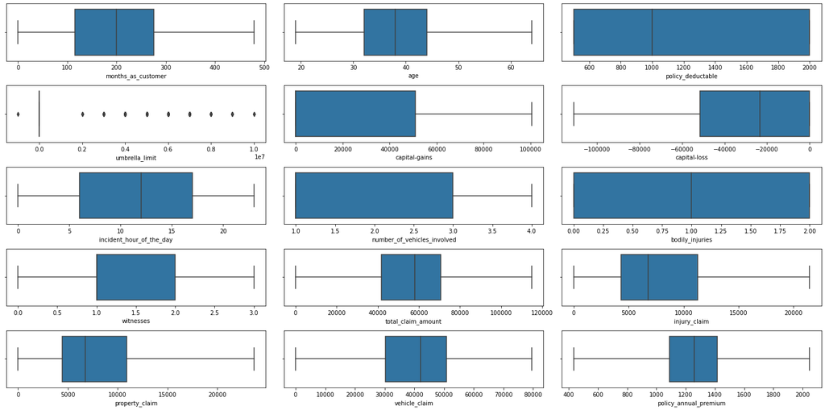

```python
# Checking for Extreme Outliers in data

fig,ax=plt.subplots(5,3,figsize=(20,10))

i,j=0,0
for col in num_index:
    sns.boxplot(data[col],ax=ax[i,j],whis=3)
    j+=1
    if j==3:
        i+=1
        j=0

fig.tight_layout()
```

```python
# It is clearly visible that we don't have any outliers at all
# Umbrella limit is showing outliers because most of the customers have 0 umbrella limit .
# However the values being shown as outliers in umbrella limit are important information , and not some random values
# There is just one outlier -- that is the negative umbrella limit value , that makes no sense whatsoever , so, we'll remove it

data.umbrella_limit.loc[data.umbrella_limit[data.umbrella_limit==-1000000].index[0]]=0
data.policy_annual_premium.loc[data.policy_annual_premium[data.policy_annual_premium==433.33].index[0]]=data.policy_annual_premium.mean()
```

### Feature Extraction & Feature Selection

```python
# Creating New Features

# claim_duration = policy_bind_date -incident_date
# car_duration = auto_year - incident_date

data['claim_duration']=(data['incident_date']-data['policy_bind_date']).dt.days
data['car_duration']=(data.incident_date-data.auto_year).dt.days

# Removing Unnecessary columns

data=data.drop(['incident_date','policy_bind_date','auto_year','auto_model'],axis=1)
```

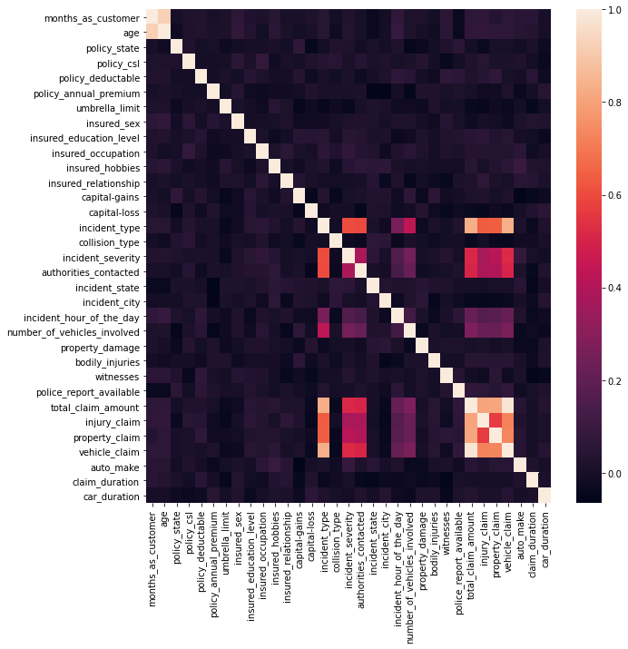

```python
# Feature Selection Methods

# Removing Highly Correlated Features
# Visualizing Pearsons Correlation Heatmap

plt.figure(figsize=(10,10))
sns.heatmap(data.drop(['fraud_reported'],axis=1).corr()) #method='spearman

# We can se that most of the features are not correlated ; which means they are independent
```

```python
# Finding Higly Correlated Columns

def correlation(data,threshold):
    col_corr=set()
    cor=data.corr()
    for i in range(len(cor.columns)):
        for j in range(len(cor.columns)):
            if (abs(cor.iloc[i,j]) > threshold) and i!=j:
                if (cor.columns[j] in col_corr) or (cor.columns[i] in col_corr):
                    continue
                print("\n",cor.columns[i],"-----",cor.columns[j])
                print(abs(cor.iloc[i,j]))
                colname=cor.columns[i]
                col_corr.add(colname)
    return col_corr

a=correlation(data.drop(['fraud_reported'],axis=1),0.9)
print('\n',a)
```

```
 months_as_customer ----- age
0.9220983225789804

 total_claim_amount ----- vehicle_claim
0.9827731790805634

 {'months_as_customer', 'total_claim_amount'}
```

```python
# Removing the higly correlated columns
data=data.drop(['age', 'total_claim_amount'],axis=1)
data.shape
```

```
(1000, 32)
```

[output not shown]

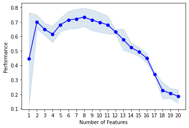

```python
# WRAPPER METHOD - SEQUENTIAL FEATURE SELECTOR

from sklearn.ensemble import RandomForestClassifier
from mlxtend.feature_selection import SequentialFeatureSelector as sfs
from mlxtend.plotting import plot_sequential_feature_selection as plot_sfs
from sklearn.neighbors import KNeighborsClassifier

sfs=sfs(KNeighborsClassifier(n_neighbors=10,weights='distance',metric='euclidean'),k_features=20,forward=True,floating=False,scoring='recall',cv=3)
sfs.fit(data.drop(['fraud_reported'],axis=1),data.fraud_reported)
plot_sfs(sfs.get_metric_dict(),kind='std_dev')
```

```python
sfs_support=[True if list(sfs.k_feature_names_).count(col)==1  else False for col in data.drop(['fraud_reported'],axis=1).columns ]
data.drop(['fraud_reported'],axis=1)[list(sfs.k_feature_names_)].columns
```

```
Index(['policy_state', 'policy_csl', 'umbrella_limit', 'insured_sex',
       'insured_education_level', 'insured_hobbies', 'insured_relationship',
       'capital-gains', 'incident_type', 'collision_type', 'incident_severity',
       'authorities_contacted', 'incident_state', 'incident_city',
       'number_of_vehicles_involved', 'property_damage', 'bodily_injuries',
       'witnesses', 'police_report_available', 'auto_make'],
      dtype='object')
```

```python
# WRAPPER METHOD - RECURSIVE FEATURE ELIMINATION

from sklearn.feature_selection import chi2 , f_classif ,mutual_info_classif,RFE

rfe=RFE(RandomForestClassifier(),n_features_to_select=20)
rfe=rfe.fit(data.drop(['fraud_reported'],axis=1),data.fraud_reported)
rfe_support=rfe.get_support()
data.drop(['fraud_reported'],axis=1).columns[rfe_support]
```

```
Index(['months_as_customer', 'policy_annual_premium',
       'insured_education_level', 'insured_occupation', 'insured_hobbies',
       'insured_relationship', 'capital-gains', 'capital-loss',
       'incident_severity', 'authorities_contacted', 'incident_state',
       'incident_city', 'incident_hour_of_the_day', 'witnesses',
       'injury_claim', 'property_claim', 'vehicle_claim', 'auto_make',
       'claim_duration', 'car_duration'],
      dtype='object')
```

```python
# INTRINSIC FEATURE SELECTION - RANDOM FOREST

from sklearn.feature_selection import SelectFromModel
from sklearn.ensemble import RandomForestClassifier

embeded_rf_selector = SelectFromModel(RandomForestClassifier(n_estimators=100), max_features=20)
embeded_rf_selector.fit(data.drop(['fraud_reported'],axis=1),data.fraud_reported)
embeded_rf_support = embeded_rf_selector.get_support()
data.drop(['fraud_reported'],axis=1).columns[rfe_support]
```

```
Index(['months_as_customer', 'policy_annual_premium',
       'insured_education_level', 'insured_occupation', 'insured_hobbies',
       'insured_relationship', 'capital-gains', 'capital-loss',
       'incident_severity', 'authorities_contacted', 'incident_state',
       'incident_city', 'incident_hour_of_the_day', 'witnesses',
       'injury_claim', 'property_claim', 'vehicle_claim', 'auto_make',
       'claim_duration', 'car_duration'],
      dtype='object')
```

```python
# INTRINSIC FEATURE SELECTION - XGBOOST

from sklearn.feature_selection import SelectFromModel
from xgboost import XGBClassifier

xgb = SelectFromModel(XGBClassifier(use_label_encoder=False,eval_metric='error'), max_features=30)
xgb.fit(data.drop(['fraud_reported'],axis=1),data.fraud_reported)
xgb_support = xgb.get_support()
data.drop(['fraud_reported'],axis=1).columns[xgb_support]
```

```
Index(['umbrella_limit', 'insured_hobbies', 'incident_severity',
       'property_damage'],
      dtype='object')
```

```python
# FILTER METHOD - CORRELATION

def cor_selector(X, y,num_feats):
    cor_list = []
    feature_name = X.columns.tolist()
    # calculate the correlation with y for each feature
    for i in X.columns.tolist():
        cor = np.corrcoef(X[i], y)[0, 1]
        cor_list.append(cor)
    # replace NaN with 0
    cor_list = [0 if np.isnan(i) else i for i in cor_list]
    # feature name
    cor_feature = X.iloc[:,np.argsort(np.abs(cor_list))[-num_feats:]].columns.tolist()
    # feature selection? 0 for not select, 1 for select
    cor_support = [True if i in cor_feature else False for i in feature_name]
    return cor_support, cor_feature


cor_support, cor_feature = cor_selector(data.drop(['fraud_reported'],axis=1),data.fraud_reported,20)
data.drop(['fraud_reported'],axis=1).columns[cor_support]
```

```
Index(['policy_state', 'policy_csl', 'umbrella_limit', 'insured_occupation',
       'insured_hobbies', 'insured_relationship', 'incident_type',
       'collision_type', 'incident_severity', 'authorities_contacted',
       'incident_state', 'incident_city', 'number_of_vehicles_involved',
       'bodily_injuries', 'witnesses', 'police_report_available',
       'injury_claim', 'property_claim', 'vehicle_claim', 'auto_make'],
      dtype='object')
```

```python
# FILTER METHOD - CHI2

from sklearn.feature_selection import SelectKBest
from sklearn.feature_selection import chi2
from sklearn.preprocessing import MinMaxScaler

X_norm = MinMaxScaler().fit_transform(data.drop(['fraud_reported'],axis=1))
chi_selector = SelectKBest(chi2, k=20)
chi_selector.fit(X_norm, data.fraud_reported)
chi_support = chi_selector.get_support()
data.drop(['fraud_reported'],axis=1).columns[chi_support]
```

```
Index(['policy_csl', 'umbrella_limit', 'insured_sex', 'insured_occupation',
       'insured_hobbies', 'insured_relationship', 'incident_type',
       'collision_type', 'incident_severity', 'authorities_contacted',
       'incident_state', 'incident_city', 'number_of_vehicles_involved',
       'property_damage', 'witnesses', 'police_report_available',
       'injury_claim', 'property_claim', 'vehicle_claim', 'auto_make'],
      dtype='object')
```

```python
feature_selection=pd.DataFrame(data={'Features':data.drop(['fraud_reported'],axis=1).columns,"Person_corr":cor_support,'CHI2':chi_support,
                                                        "SFS":sfs_support,'RFE':rfe_support,'Rand-Forest':embeded_rf_support,"XGB":xgb_support})
feature_selection['Total'] = np.sum(feature_selection, axis=1)

feature_selection_df = feature_selection.sort_values(['Total'] , ascending=False)
feature_selection_df.index = range(1, len(feature_selection_df)+1)
feature_selection_df
```

|  | Features | Person_corr | CHI2 | SFS | RFE | Rand-Forest | XGB | Total |
| --- | --- | --- | --- | --- | --- | --- | --- | --- |
| 1 | incident_severity | True | True | True | True | True | True | 6 |
| 2 | insured_hobbies | True | True | True | True | True | True | 6 |
| 3 | insured_occupation | True | True | False | True | True | False | 4 |
| 4 | incident_city | True | True | True | True | False | False | 4 |
| 5 | incident_state | True | True | True | True | False | False | 4 |
| 6 | authorities_contacted | True | True | True | True | False | False | 4 |
| 7 | witnesses | True | True | True | True | False | False | 4 |
| 8 | injury_claim | True | True | False | True | True | False | 4 |
| 9 | insured_relationship | True | True | True | True | False | False | 4 |
| 10 | property_claim | True | True | False | True | True | False | 4 |
| 11 | vehicle_claim | True | True | False | True | True | False | 4 |
| 12 | umbrella_limit | True | True | True | False | False | True | 4 |
| 13 | auto_make | True | True | True | True | False | False | 4 |
| 14 | property_damage | False | True | True | False | False | True | 3 |
| 15 | police_report_available | True | True | True | False | False | False | 3 |
| 16 | incident_type | True | True | True | False | False | False | 3 |
| 17 | collision_type | True | True | True | False | False | False | 3 |
| 18 | policy_csl | True | True | True | False | False | False | 3 |
| 19 | number_of_vehicles_involved | True | True | True | False | False | False | 3 |
| 20 | claim_duration | False | False | False | True | True | False | 2 |
| 21 | bodily_injuries | True | False | True | False | False | False | 2 |
| 22 | months_as_customer | False | False | False | True | True | False | 2 |
| 23 | policy_state | True | False | True | False | False | False | 2 |
| 24 | capital-gains | False | False | True | True | False | False | 2 |
| 25 | insured_education_level | False | False | True | True | False | False | 2 |
| 26 | insured_sex | False | True | True | False | False | False | 2 |
| 27 | policy_annual_premium | False | False | False | True | True | False | 2 |
| 28 | car_duration | False | False | False | True | True | False | 2 |
| 29 | incident_hour_of_the_day | False | False | False | True | False | False | 1 |
| 30 | capital-loss | False | False | False | True | False | False | 1 |
| 31 | policy_deductable | False | False | False | False | False | False | 0 |

```python
# We take the top 20 features

feature_selection_df.loc[:20,'Features'].values
```

```
array(['incident_severity', 'insured_hobbies', 'insured_occupation',
       'incident_city', 'incident_state', 'authorities_contacted',
       'witnesses', 'injury_claim', 'insured_relationship',
       'property_claim', 'vehicle_claim', 'umbrella_limit', 'auto_make',
       'property_damage', 'police_report_available', 'incident_type',
       'collision_type', 'policy_csl', 'number_of_vehicles_involved',
       'claim_duration'], dtype=object)
```

```python
# Reordering Data

data=data[[ 'incident_type','collision_type','incident_severity', 'auto_make','incident_state', 'incident_city','number_of_vehicles_involved'
            , 'authorities_contacted','witnesses','police_report_available',
            'property_claim','vehicle_claim', 'injury_claim','property_damage',
            'policy_csl','umbrella_limit','claim_duration',
            'insured_occupation', 'insured_relationship','insured_hobbies','fraud_reported']]
```

### Handling Imbalance

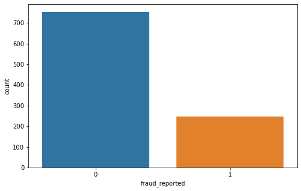

```python
# Checking for Imbalance

fig=plt.figure(figsize=(8,5))
sns.countplot(data.fraud_reported)
```

```python
from imblearn.over_sampling import SMOTE

X=data.drop(['fraud_reported'],axis=1)
y=data['fraud_reported']
smote=SMOTE(k_neighbors=10,sampling_strategy='minority')
X,y=smote.fit_resample(X,y)
```

```python
data=pd.merge(X,y,left_index=True,right_index=True)
data
```

|  | incident_type | collision_type | incident_severity | auto_make | incident_state | incident_city | number_of_vehicles_involved | authorities_contacted | witnesses | police_report_available | property_claim | vehicle_claim | injury_claim | property_damage | policy_csl | umbrella_limit | claim_duration | insured_occupation | insured_relationship | insured_hobbies | fraud_reported |
| --- | --- | --- | --- | --- | --- | --- | --- | --- | --- | --- | --- | --- | --- | --- | --- | --- | --- | --- | --- | --- | --- |
| 0 | 403 | 0.233038 | 8 | 0.225000 | 0.294355 | 0.261745 | 1 | 6 | 2 | 1 | 13020 | 52080 | 6510 | 1 | 0.262108 | 0 | 100 | 16 | 0.205882 | 0.195122 | 1 |
| 1 | 94 | 0.233038 | 6 | 0.338462 | 0.227273 | 0.223881 | 1 | 6 | 0 | 1 | 780 | 3510 | 780 | 1 | 0.262108 | 5000000 | 3130 | 11 | 0.293785 | 0.265625 | 1 |
| 2 | 419 | 0.267409 | 6 | 0.250000 | 0.221374 | 0.261745 | 3 | 6 | 3 | 0 | 3850 | 23100 | 7700 | 0 | 0.257880 | 5000000 | 5282 | 13 | 0.213115 | 0.291667 | 0 |
| 3 | 403 | 0.238411 | 8 | 0.276316 | 0.434783 | 0.289474 | 1 | 6 | 2 | 0 | 6340 | 50720 | 6340 | 0 | 0.262108 | 6000000 | 8996 | 12 | 0.241135 | 0.291667 | 1 |
| 4 | 94 | 0.267409 | 6 | 0.191176 | 0.221374 | 0.289474 | 1 | 5 | 1 | 0 | 650 | 4550 | 1300 | 0 | 0.216667 | 6000000 | 256 | 13 | 0.241135 | 0.291667 | 0 |
| ... | ... | ... | ... | ... | ... | ... | ... | ... | ... | ... | ... | ... | ... | ... | ... | ... | ... | ... | ... | ... | ... |
| 1501 | 419 | 0.241755 | 6 | 0.229043 | 0.285937 | 0.244311 | 3 | 9 | 1 | 0 | 12615 | 46099 | 7475 | 0 | 0.221420 | 6000000 | 3920 | 7 | 0.291154 | 0.751161 | 1 |
| 1502 | 417 | 0.241945 | 7 | 0.235977 | 0.179724 | 0.236158 | 2 | 7 | 2 | 0 | 5792 | 51357 | 11585 | 1 | 0.216667 | 0 | 2844 | 14 | 0.218661 | 0.199145 | 1 |
| 1503 | 419 | 0.234608 | 8 | 0.297441 | 0.179724 | 0.243042 | 2 | 6 | 1 | 0 | 7454 | 52179 | 9627 | 0 | 0.259115 | 8292129 | 2894 | 15 | 0.205882 | 0.254654 | 1 |
| 1504 | 415 | 0.267409 | 8 | 0.250631 | 0.277868 | 0.230445 | 2 | 8 | 1 | 0 | 9787 | 40173 | 4893 | 1 | 0.225977 | 0 | 3490 | 15 | 0.246707 | 0.252047 | 1 |
| 1505 | 403 | 0.238411 | 7 | 0.261802 | 0.294355 | 0.260058 | 1 | 7 | 1 | 0 | 18790 | 69211 | 9395 | 0 | 0.216667 | 0 | 5285 | 10 | 0.250779 | 0.440759 | 1 |

1506 rows × 21 columns

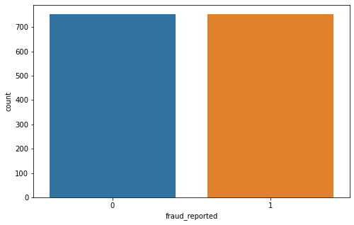

```python
fig=plt.figure(figsize=(8,5))
sns.countplot(data.fraud_reported)
```

### Clustering

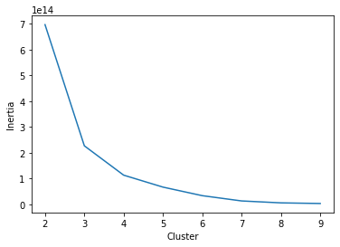

```python
# Elbow curve ,to determine optimal no. of clusters
# Clustering data to fit separate models on the different clusters , to check if  model generalises better after clustering , or as a whole

from sklearn.cluster import dbscan,KMeans

inertia=[]
for k in range(2,10):
    cluster=KMeans(n_clusters=k,n_init=10)
    cluster.fit(data)
    inertia.append(cluster.inertia_)

elbow=pd.DataFrame(data={'Cluster':range(2,10),'Inertia':inertia})
sns.lineplot(x=elbow.Cluster,y=elbow.Inertia)
```

```python
#From above elbow curve , optimal no. of clusters is 4

from sklearn.cluster import KMeans

kmeans=KMeans(n_clusters=4)
kmeans.fit(data.drop(['fraud_reported'],axis=1))
data['Cluster']=kmeans.predict(data.drop(['fraud_reported'],axis=1))
data.head()
```

|  | incident_type | collision_type | incident_severity | auto_make | incident_state | incident_city | number_of_vehicles_involved | authorities_contacted | witnesses | police_report_available | property_claim | vehicle_claim | injury_claim | property_damage | policy_csl | umbrella_limit | claim_duration | insured_occupation | insured_relationship | insured_hobbies | fraud_reported | Cluster |
| --- | --- | --- | --- | --- | --- | --- | --- | --- | --- | --- | --- | --- | --- | --- | --- | --- | --- | --- | --- | --- | --- | --- |
| 0 | 403 | 0.233038 | 8 | 0.225000 | 0.294355 | 0.261745 | 1 | 6 | 2 | 1 | 13020 | 52080 | 6510 | 1 | 0.262108 | 0 | 100 | 16 | 0.205882 | 0.195122 | 1 | 0 |
| 1 | 94 | 0.233038 | 6 | 0.338462 | 0.227273 | 0.223881 | 1 | 6 | 0 | 1 | 780 | 3510 | 780 | 1 | 0.262108 | 5000000 | 3130 | 11 | 0.293785 | 0.265625 | 1 | 1 |
| 2 | 419 | 0.267409 | 6 | 0.250000 | 0.221374 | 0.261745 | 3 | 6 | 3 | 0 | 3850 | 23100 | 7700 | 0 | 0.257880 | 5000000 | 5282 | 13 | 0.213115 | 0.291667 | 0 | 1 |
| 3 | 403 | 0.238411 | 8 | 0.276316 | 0.434783 | 0.289474 | 1 | 6 | 2 | 0 | 6340 | 50720 | 6340 | 0 | 0.262108 | 6000000 | 8996 | 12 | 0.241135 | 0.291667 | 1 | 1 |
| 4 | 94 | 0.267409 | 6 | 0.191176 | 0.221374 | 0.289474 | 1 | 5 | 1 | 0 | 650 | 4550 | 1300 | 0 | 0.216667 | 6000000 | 256 | 13 | 0.241135 | 0.291667 | 0 | 1 |

```python
# cluster labels
set(kmeans.labels_)
```

```
{0, 1, 2, 3}
```

```python
data.Cluster.value_counts()
```

```
0    1174
1     157
2      96
3      79
Name: Cluster, dtype: int64
```

```python
data_c1=data[data.Cluster==0].drop(['Cluster'],axis=1).copy(deep=True)
data_c2=data[data.Cluster==1].drop(['Cluster'],axis=1).copy(deep=True)
data_c3=data[data.Cluster==2].drop(['Cluster'],axis=1).copy(deep=True)
data_c4=data[data.Cluster==3].drop(['Cluster'],axis=1).copy(deep=True)
```

```python
data=data.drop(['Cluster'],axis=1)
```

### TRYING AND COMPARING PERFORMANCE OF DIFFERENT MODELS

```python
#Classification Models to try :
""" Logistic Regression , KNN , SVM , Naive Bayes Classifier , Dtree Classifier, XGB classifier , rand-forest classifier , AdaBoost , Bagging Classifier """
```

```
' Logistic Regression , KNN , SVM , Naive Bayes Classifier , Dtree Classifier, XGB classifier , rand-forest classifier , AdaBoost , Bagging Classifier '
```

```python
# Evaluation metric for models -Recall ( Since , it is important to classify all frauds as frauds , else the company will ncur huge losses )
# From the Company's point of view , it is much reasonable to choose Recall as metric
# From the customers point of view , it is easonable to choose Precision -- since we want to see - how trustable the model in terms of predicting fraud (Out of the predicted frauds , how many are actually frauds)

# we want a sweet spot b/w recall and precision , with more emphasis on improving Recall
```

```python
#Trying Logistic Regression

import numpy as np
from sklearn.model_selection import train_test_split
from sklearn.linear_model import LogisticRegression
from sklearn.metrics import recall_score,accuracy_score,roc_auc_score
from sklearn.model_selection import cross_val_score , RepeatedStratifiedKFold

scores_logreg=[]
accuracy_logreg=[]

# Standardizing the data

from sklearn.preprocessing import StandardScaler
scaler=StandardScaler()

for i in [data,data_c1,data_c2,data_c3,data_c4]:
        X=i.drop(['fraud_reported'],axis=1)
        X=scaler.fit_transform(X)
        y=i.fraud_reported

        logreg=LogisticRegression(max_iter=1000,solver='newton-cg')
        cv=RepeatedStratifiedKFold(n_splits=10, n_repeats=5,random_state=1)

        #collecting recall
        recall=cross_val_score(logreg,X,y,cv=cv,scoring='recall')
        scores_logreg.append(recall.mean())

        #collecting accuracy
        acc=cross_val_score(logreg,X,y,cv=cv,scoring='accuracy')
        accuracy_logreg.append(acc.mean())

print(f"Cross Validation Score : \n")
print(f"Entire Data--Recall:{scores_logreg[0]}  Accuracy :{accuracy_logreg[0]} ")
print(f"Cluster 1--Recall:{scores_logreg[1]}  Accuracy :{accuracy_logreg[1]} ")
print(f"Cluster 2--Recall:{scores_logreg[2]}  Accuracy :{accuracy_logreg[2]} ")
print(f"Cluster 3--Recall:{scores_logreg[3]}  Accuracy :{accuracy_logreg[3]} ")
print(f"Cluster 4--Recall:{scores_logreg[4]}  Accuracy :{accuracy_logreg[4]} ")
```

```
Cross Validation Score :

Entire Data--Recall:0.8387859649122809  Accuracy :0.8297271523178807
Cluster 1--Recall:0.8160025062656641  Accuracy :0.8177241778936694
Cluster 2--Recall:0.9083333333333334  Accuracy :0.8754166666666667
Cluster 3--Recall:0.9093333333333333  Accuracy :0.8437777777777778
Cluster 4--Recall:0.9760000000000001  Accuracy :0.8942857142857144
```

```python
# Trying KNN Classifier

from sklearn.neighbors import KNeighborsClassifier

scores_knn=[]
accuracy_knn=[]

scaler=StandardScaler()

for i in [data,data_c1,data_c2,data_c3,data_c4]:
        X=i.drop(['fraud_reported'],axis=1)
        X=scaler.fit_transform(X)
        y=i.fraud_reported

        knn=KNeighborsClassifier(n_neighbors=10,weights='distance',metric='euclidean')
        cv=RepeatedStratifiedKFold(n_splits=10, n_repeats=5,random_state=1)

        #collecting recall
        recall=cross_val_score(knn,X,y,cv=cv,scoring='recall')
        scores_knn.append(recall.mean())

        #collecting accuracy
        acc=cross_val_score(knn,X,y,cv=cv,scoring='accuracy')
        accuracy_knn.append(acc.mean())


print(f"Cross Validation Score : \n")
print(f"Entire Data : {scores_knn[0]}  Accuracy : {accuracy_knn[0]}")
print(f"Cluster 1---Recall : {scores_knn[1]}  Accuracy : {accuracy_knn[1]}")
print(f"Cluster 2---Recall : {scores_knn[2]}  Accuracy : {accuracy_knn[2]}")
print(f"Cluster 3---Recall : {scores_knn[3]}  Accuracy : {accuracy_knn[3]}")
print(f"Cluster 4---Recall : {scores_knn[4]}  Accuracy : {accuracy_knn[4]}")
```

```
Cross Validation Score :

Entire Data : 0.9545894736842107  Accuracy : 0.7918949227373069
Cluster 1---Recall : 0.9498496240601503  Accuracy : 0.7882514848616543
Cluster 2---Recall : 0.9583333333333335  Accuracy : 0.8137499999999999
Cluster 3---Recall : 0.9833333333333334  Accuracy : 0.7506666666666665
Cluster 4---Recall : 1.0  Accuracy : 0.7878571428571429
```

```python
# Trying SVM Classifier

from sklearn.svm import SVC,LinearSVC

scores_svc=[]
accuracy_svc=[]

scaler=StandardScaler()

for i in [data,data_c1,data_c2,data_c3,data_c4]:
        X=i.drop(['fraud_reported'],axis=1)
        X=scaler.fit_transform(X)
        y=i.fraud_reported

        svc=SVC(C=1, kernel="poly", degree=4)
        cv=RepeatedStratifiedKFold(n_splits=10, n_repeats=5,random_state=1)

        #collecting recall
        recall=cross_val_score(svc,X,y,cv=cv,scoring='recall')
        scores_svc.append(recall.mean())

        #collecting accuracy
        acc=cross_val_score(svc,X,y,cv=cv,scoring='accuracy')
        accuracy_svc.append(acc.mean())

print(f"Cross Validation Score : \n")
print(f"Entire Data : {scores_svc[0]}  Accuracy : {accuracy_svc[0]}")
print(f"Cluster 1---Recall : {scores_svc[1]}  Accuracy : {accuracy_svc[1]}")
print(f"Cluster 2---Recall : {scores_svc[2]}  Accuracy : {accuracy_svc[2]}")
print(f"Cluster 3---Recall : {scores_svc[3]}  Accuracy : {accuracy_svc[3]}")
print(f"Cluster 4---Recall : {scores_svc[4]}  Accuracy : {accuracy_svc[4]}")
```

```
Cross Validation Score :

Entire Data : 0.9356877192982455  Accuracy : 0.7803487858719648
Cluster 1---Recall : 0.929874686716792  Accuracy : 0.7817601043024771
Cluster 2---Recall : 0.9363888888888888  Accuracy : 0.6646666666666667
Cluster 3---Recall : 1.0  Accuracy : 0.6671111111111111
Cluster 4---Recall : 1.0  Accuracy : 0.7396428571428573
```

```python
# Trying Naive Bayes

from sklearn.naive_bayes import MultinomialNB , GaussianNB

scores_nb=[]
accuracy_nb=[]

for i in [data,data_c1,data_c2,data_c3,data_c4]:
        X=i.drop(['fraud_reported'],axis=1)
        X=scaler.fit_transform(X)
        y=i.fraud_reported

        nb=GaussianNB()
        cv=RepeatedStratifiedKFold(n_splits=10, n_repeats=5,random_state=1)

        #collecting recall
        recall=cross_val_score(nb,X,y,cv=cv,scoring='recall')
        scores_nb.append(recall.mean())

        #collecting accuracy
        acc=cross_val_score(nb,X,y,cv=cv,scoring='accuracy')
        accuracy_nb.append(acc.mean())

print(f"Cross Validation Score : \n")
print(f"Entire Data : {scores_nb[0]}  Accuracy : {accuracy_nb[0]}")
print(f"Cluster 1---Recall : {scores_nb[1]}  Accuracy : {accuracy_nb[1]}")
print(f"Cluster 2---Recall : {scores_nb[2]}  Accuracy : {accuracy_nb[2]}")
print(f"Cluster 3---Recall : {scores_nb[3]}  Accuracy : {accuracy_nb[3]}")
print(f"Cluster 4---Recall : {scores_nb[4]}  Accuracy : {accuracy_nb[4]}")
```

```
Cross Validation Score :

Entire Data : 0.883361403508772  Accuracy : 0.7820335540838853
Cluster 1---Recall : 0.8743734335839599  Accuracy : 0.7698478922207735
Cluster 2---Recall : 0.9  Accuracy : 0.8233333333333331
Cluster 3---Recall : 0.8673333333333333  Accuracy : 0.7984444444444445
Cluster 4---Recall : 0.9279999999999998  Accuracy : 0.8685714285714284
```

```python
#Trying Bagging Classifier

from sklearn.ensemble import BaggingClassifier

scores_bgc=[]
accuracy_bgc=[]

for i in [data,data_c1,data_c2,data_c3,data_c4]:
        X=i.drop(['fraud_reported'],axis=1)
        X=scaler.fit_transform(X)
        y=i.fraud_reported

        bgc=BaggingClassifier(base_estimator=KNeighborsClassifier(n_neighbors=10,weights='distance',metric='euclidean'), n_estimators=20, max_samples=0.7)
        cv=RepeatedStratifiedKFold(n_splits=10, n_repeats=5,random_state=1)

        #collecting recall
        recall=cross_val_score(bgc,X,y,cv=cv,scoring='recall')
        scores_bgc.append(recall.mean())

        #collecting accuracy
        acc=cross_val_score(bgc,X,y,cv=cv,scoring='accuracy')
        accuracy_bgc.append(acc.mean())

print(f"Cross Validation Score : \n")
print(f"Entire Data : {scores_bgc[0]}  Accuracy : {accuracy_bgc[0]}")
print(f"Cluster 1---Recall : {scores_bgc[1]}  Accuracy : {accuracy_bgc[1]}")
print(f"Cluster 2---Recall : {scores_bgc[2]}  Accuracy : {accuracy_bgc[2]}")
print(f"Cluster 3---Recall : {scores_bgc[3]}  Accuracy : {accuracy_bgc[3]}")
print(f"Cluster 4---Recall : {scores_bgc[4]}  Accuracy : {accuracy_bgc[4]}")
```

```
Cross Validation Score :

Entire Data : 0.9508666666666664  Accuracy : 0.7803364238410595
Cluster 1---Recall : 0.9455701754385964  Accuracy : 0.776333478197885
Cluster 2---Recall : 0.9533333333333335  Accuracy : 0.7844999999999999
Cluster 3---Recall : 0.9833333333333334  Accuracy : 0.6697777777777776
Cluster 4---Recall : 1.0  Accuracy : 0.7678571428571429
```

```python
#Trying Random Forest

from sklearn.ensemble import RandomForestClassifier

scores_rf=[]
accuracy_rf=[]

for i in [data,data_c1,data_c2,data_c3,data_c4]:
        X=i.drop(['fraud_reported'],axis=1)
        y=i.fraud_reported

        rf=RandomForestClassifier()
        cv=RepeatedStratifiedKFold(n_splits=10, n_repeats=5,random_state=1)

        #collecting recall
        recall=cross_val_score(rf,X,y,cv=cv,scoring='recall')
        scores_rf.append(recall.mean())

        #collecting accuracy
        acc=cross_val_score(rf,X,y,cv=cv,scoring='accuracy')
        accuracy_rf.append(acc.mean())

print(f"Cross Validation Score : \n")
print(f"Entire Data : {scores_rf[0]}  Accuracy : {accuracy_rf[0]}")
print(f"Cluster 1---Recall : {scores_rf[1]}  Accuracy : {accuracy_rf[1]}")
print(f"Cluster 2---Recall : {scores_rf[2]}  Accuracy : {accuracy_rf[2]}")
print(f"Cluster 3---Recall : {scores_rf[3]}  Accuracy : {accuracy_rf[3]}")
print(f"Cluster 4---Recall : {scores_rf[4]}  Accuracy : {accuracy_rf[4]}")
```

```
Cross Validation Score :

Entire Data : 0.9179228070175438  Accuracy : 0.8990596026490065
Cluster 1---Recall : 0.8936528822055139  Accuracy : 0.890311458786035
Cluster 2---Recall : 0.8808333333333335  Accuracy : 0.8750833333333332
Cluster 3---Recall : 0.9286666666666668  Accuracy : 0.8644444444444445
Cluster 4---Recall : 0.9359999999999999  Accuracy : 0.8635714285714284
```

```python
#Trying ADABOOST WITH DTREE

from sklearn.ensemble import AdaBoostClassifier
from sklearn.tree import DecisionTreeClassifier

scores_adb_dtree=[]
accuracy_adb_dtree=[]

for i in [data,data_c1,data_c2,data_c3,data_c4]:
        X=i.drop(['fraud_reported'],axis=1)
        y=i.fraud_reported
        X_train,X_test,y_train,y_test=train_test_split(X,np.ravel(y),test_size=0.3,random_state=2)

        adb_dtree=AdaBoostClassifier(base_estimator=DecisionTreeClassifier(max_depth=10,min_samples_leaf=5), n_estimators=50, learning_rate=0.3, algorithm="SAMME.R")
        cv=RepeatedStratifiedKFold(n_splits=10, n_repeats=3,random_state=1)

        #collecting recall
        recall=cross_val_score(adb_dtree,X,y,cv=cv,scoring='recall')
        scores_adb_dtree.append(recall.mean())

        #collecting accuracy
        acc=cross_val_score(adb_dtree,X,y,cv=cv,scoring='accuracy')
        accuracy_adb_dtree.append(acc.mean())

print(f"Cross Validation Score : \n")
print(f"Entire Data : {scores_adb_dtree[0]}  Accuracy : {accuracy_adb_dtree[0]}")
print(f"Cluster 1---Recall : {scores_adb_dtree[1]}  Accuracy : {accuracy_adb_dtree[1]}")
print(f"Cluster 2---Recall : {scores_adb_dtree[2]}  Accuracy : {accuracy_adb_dtree[2]}")
print(f"Cluster 3---Recall : {scores_adb_dtree[3]}  Accuracy : {accuracy_adb_dtree[3]}")
print(f"Cluster 4---Recall : {scores_adb_dtree[4]}  Accuracy : {accuracy_adb_dtree[4]}")
```

```
Cross Validation Score :

Entire Data : 0.8897251461988306  Accuracy : 0.8806725533480501
Cluster 1---Recall : 0.8730680868838764  Accuracy : 0.8781713264764114
Cluster 2---Recall : 0.8819444444444445  Accuracy : 0.8790277777777777
Cluster 3---Recall : 0.95  Accuracy : 0.9144444444444445
Cluster 4---Recall : 0.9466666666666668  Accuracy : 0.8482142857142858
```

```python
#Trying XGB Classsifier

from xgboost import XGBClassifier

scores_xgb=[]
accuracy_xgb=[]

for i in [data,data_c1,data_c2,data_c3,data_c4]:
        X=i.drop(['fraud_reported'],axis=1)
        y=i.fraud_reported
        X_train,X_test,y_train,y_test=train_test_split(X,np.ravel(y),test_size=0.3,random_state=2)

        xgb=XGBClassifier(use_label_encoder=False ,eval_metric='error')
        cv=RepeatedStratifiedKFold(n_splits=10, n_repeats=3,random_state=1)

        #collecting recall
        recall=cross_val_score(xgb,X,y,cv=cv,scoring='recall')
        scores_xgb.append(recall.mean())

        #collecting accuracy
        acc=cross_val_score(xgb,X,y,cv=cv,scoring='accuracy')
        accuracy_xgb.append(acc.mean())

print(f"Cross Validation Score : \n")
print(f"Entire Data : {scores_xgb[0]}  Accuracy : {accuracy_xgb[0]}")
print(f"Cluster 1---Recall : {scores_xgb[1]}  Accuracy : {accuracy_xgb[1]}")
print(f"Cluster 2---Recall : {scores_xgb[2]}  Accuracy : {accuracy_xgb[2]}")
print(f"Cluster 3---Recall : {scores_xgb[3]}  Accuracy : {accuracy_xgb[3]}")
print(f"Cluster 4---Recall : {scores_xgb[4]}  Accuracy : {accuracy_xgb[4]}")
```

```
Cross Validation Score :

Entire Data : 0.9060935672514622  Accuracy : 0.8992641648270786
Cluster 1---Recall : 0.8956035923141186  Accuracy : 0.8903954802259888
Cluster 2---Recall : 0.8819444444444445  Accuracy : 0.8680555555555556
Cluster 3---Recall : 0.9655555555555556  Accuracy : 0.917037037037037
Cluster 4---Recall : 0.9266666666666666  Accuracy : 0.8434523809523811
```

```python
# Comparing Recall Values

recall_vals=pd.DataFrame(data=[scores_logreg,scores_knn,scores_svc,
                        scores_nb,scores_bgc,scores_rf,scores_adb_dtree,scores_xgb],
                        index=['Logreg_recall','knn_recall','svc_recall',
                        'nb_recall','bgc_recall','rf_recall','adb_dtree_recall','xgb_recall'],
                        columns=['Entire Data','Cluster 1','Cluster 2','Cluster 3','Cluster 4'])

recall_vals
```

|  | Entire Data | Cluster 1 | Cluster 2 | Cluster 3 | Cluster 4 |
| --- | --- | --- | --- | --- | --- |
| Logreg_recall | 0.838786 | 0.816003 | 0.908333 | 0.909333 | 0.976000 |
| knn_recall | 0.954589 | 0.949850 | 0.958333 | 0.983333 | 1.000000 |
| svc_recall | 0.935688 | 0.929875 | 0.936389 | 1.000000 | 1.000000 |
| nb_recall | 0.883361 | 0.874373 | 0.900000 | 0.867333 | 0.928000 |
| bgc_recall | 0.950867 | 0.945570 | 0.953333 | 0.983333 | 1.000000 |
| rf_recall | 0.917923 | 0.893653 | 0.880833 | 0.928667 | 0.936000 |
| adb_dtree_recall | 0.889725 | 0.873068 | 0.881944 | 0.950000 | 0.946667 |
| xgb_recall | 0.906094 | 0.895604 | 0.881944 | 0.965556 | 0.926667 |

```python
# Comparing Accuracy Values

accuracy_vals=pd.DataFrame(data=[accuracy_logreg,accuracy_knn,accuracy_svc,
                        accuracy_nb,accuracy_bgc,accuracy_rf,accuracy_adb_dtree,accuracy_xgb],
                        index=['Logreg_accuracy','knn_accuracy','svc_accuracy',
                        'nb_accuracy','bgc_accuracy','rf_accuracy','adb_dtree_accuracy','xgb_accuracy'],
                        columns=['Entire Data','Cluster 1','Cluster 2','Cluster 3','Cluster 4'])

accuracy_vals
```

|  | Entire Data | Cluster 1 | Cluster 2 | Cluster 3 | Cluster 4 |
| --- | --- | --- | --- | --- | --- |
| Logreg_accuracy | 0.829727 | 0.817724 | 0.875417 | 0.843778 | 0.894286 |
| knn_accuracy | 0.791895 | 0.788251 | 0.813750 | 0.750667 | 0.787857 |
| svc_accuracy | 0.780349 | 0.781760 | 0.664667 | 0.667111 | 0.739643 |
| nb_accuracy | 0.782034 | 0.769848 | 0.823333 | 0.798444 | 0.868571 |
| bgc_accuracy | 0.780336 | 0.776333 | 0.784500 | 0.669778 | 0.767857 |
| rf_accuracy | 0.899060 | 0.890311 | 0.875083 | 0.864444 | 0.863571 |
| adb_dtree_accuracy | 0.880673 | 0.878171 | 0.879028 | 0.914444 | 0.848214 |
| xgb_accuracy | 0.899264 | 0.890395 | 0.868056 | 0.917037 | 0.843452 |

```python
for i in recall_vals.columns:
    print(f"Best Recall for {i} : {recall_vals[i].idxmax()}---- Recall : {recall_vals.loc[recall_vals[i].idxmax(),i]} ----- Accuracy : {accuracy_vals.reset_index().loc[recall_vals[i].reset_index()[i].idxmax(),i]}")
```

```
Best Recall for Entire Data : knn_recall---- Recall : 0.9545894736842107 ----- Accuracy : 0.7918949227373069
Best Recall for Cluster 1 : knn_recall---- Recall : 0.9498496240601503 ----- Accuracy : 0.7882514848616543
Best Recall for Cluster 2 : knn_recall---- Recall : 0.9583333333333335 ----- Accuracy : 0.8137499999999999
Best Recall for Cluster 3 : svc_recall---- Recall : 1.0 ----- Accuracy : 0.6671111111111111
Best Recall for Cluster 4 : knn_recall---- Recall : 1.0 ----- Accuracy : 0.7878571428571429
```

```python
for i in accuracy_vals.columns:
    print(f"Best Accuracy for {i} : {accuracy_vals[i].idxmax()}---- Accuracy :  {accuracy_vals.loc[accuracy_vals[i].idxmax(),i]}----Recall : {recall_vals.reset_index().loc[accuracy_vals[i].reset_index()[i].idxmax(),i]}")
```

```
Best Accuracy for Entire Data : xgb_accuracy---- Accuracy :  0.8992641648270786----Recall : 0.9060935672514622
Best Accuracy for Cluster 1 : xgb_accuracy---- Accuracy :  0.8903954802259888----Recall : 0.8956035923141186
Best Accuracy for Cluster 2 : adb_dtree_accuracy---- Accuracy :  0.8790277777777777----Recall : 0.8819444444444445
Best Accuracy for Cluster 3 : xgb_accuracy---- Accuracy :  0.917037037037037----Recall : 0.9655555555555556
Best Accuracy for Cluster 4 : Logreg_accuracy---- Accuracy :  0.8942857142857144----Recall : 0.9760000000000001
```